# Background and introduction

```python
#Class to clean the data
# 1. data split,
# 2. convert categorical attribute to numerical data
class DataProcessor:
    """
    Class to clean the data if necessary.
    """
    def __init__(self):
        pass
    def getDummyVarsDF(self, df, dummy_fields, drop_fields = True, convert_label = False, label = "label"):
        """
        Clean the data, convert catagories to dummy variables
        :param df: dataframe to process
        :param dummy_fields: columne names containing catagory attributes
        :param drop_fields: drop the categorical fields or not, default is True
        :param convert_label: convert the label if necessary, default is False
        :return: cleaned dataframe
        """
        label_dict = {}
        for each in dummy_fields:
            dummies = pd.get_dummies(df[each], prefix=each, drop_first=False)
            df = pd.concat([df, dummies], axis=1)

        if drop_fields:
            df = self.dropAttributes(df, dummy_fields)
        if convert_label:
            df[label] = df[label].astype('category')
            label_dict = dict(enumerate(df[label].cat.categories))
            df[label] = df[label].cat.codes
        return df, label_dict
    def splitData(self, df, split_ratio = 0.9):
        """
        Shuffle the data, then split the data to training and testing dataset
        :param df: dataframe to process
        :param split_ratio: spdefault is .9
        :return: train and test dataset
        """
        rows = df.shape[0]
        cols = df.shape[1]
        print('number of rows:{}\nnumber of columns:{}'.format(rows, cols))
        indices = np.random.permutation(rows)
        train_idx, test_idx = indices[:int(rows * split_ratio)], indices[int(rows * split_ratio):]
        train, test = df.iloc[train_idx,:], df.iloc[test_idx,:]
        print('training data shape:{}'.format(train.shape))
        print('testing data shape:{}'.format(test.shape))
        return train, test

    def getXY(self, data, label = "label", idx = 1):
        """
        Split the data to x attributes and target
        :param data: dataframe to process
        :param label: the label of the target
        :param idx: by default, assume the label is at the index 0
        :return: trainX and trainY
        """
        Y = data[label]
        X = data.iloc[:,idx:,]
        return X, Y
    def dropAttributes(self, df, col_names):
        """
        Drop specific columns of da dataframe given colmun names.
        :param df: dataframe to process
        :param col_names: the column names needs to be dropped
        :return: new dataframe after drop
        """
        if set(col_names).issubset(set(list(df.columns.values))):
            df = df.drop(col_names, axis=1)
        else:
            print("Error: Unknown attributes.")
        return df
```

```python
type(labels)
```

```
pandas.core.series.Series
```

```python
dp = DataProcessor()
labels = pd.DataFrame(labels)
x_df = pd.DataFrame(x)
new_df = pd.concat([labels, x_df],axis = 1)
```

```python
new_df.head()
```

|  | species | 0 | 1 | 2 | 3 | 4 | 5 | 6 | 7 | 8 | ... | 77 | 78 | 79 | 80 | 81 | 82 | 83 | 84 | 85 | 86 |
| --- | --- | --- | --- | --- | --- | --- | --- | --- | --- | --- | --- | --- | --- | --- | --- | --- | --- | --- | --- | --- | --- |
| 0 | Acer_Opalus | -0.034391 | -0.044043 | -0.078234 | 0.015091 | 0.014542 | 0.026259 | 0.012217 | 0.043066 | 0.026620 | ... | -0.011991 | 0.003748 | -0.002624 | 0.004250 | 0.001466 | -0.004811 | 0.002442 | 0.014184 | -0.001549 | -0.001423 |
| 1 | Pterocarya_Stenoptera | -0.098290 | -0.076697 | -0.016510 | -0.018842 | -0.009512 | 0.006152 | 0.028564 | 0.048211 | -0.062750 | ... | -0.008357 | 0.007422 | -0.003405 | -0.009408 | 0.008560 | 0.000093 | 0.008914 | -0.004657 | 0.001453 | 0.002553 |
| 2 | Quercus_Hartwissiana | 0.087150 | -0.084009 | 0.072021 | -0.018492 | 0.038819 | 0.024141 | -0.074831 | 0.049646 | -0.048841 | ... | -0.004943 | 0.010258 | -0.015466 | 0.000338 | 0.016728 | 0.004127 | -0.003324 | 0.007214 | 0.004378 | -0.007164 |
| 3 | Tilia_Tomentosa | -0.095144 | -0.087834 | -0.069639 | -0.005416 | 0.067378 | 0.055953 | 0.079994 | 0.033601 | -0.060079 | ... | 0.007406 | 0.001521 | 0.015727 | 0.006883 | 0.008101 | 0.007886 | 0.009931 | -0.005962 | 0.000633 | -0.002616 |
| 4 | Quercus_Variabilis | 0.087992 | -0.079204 | 0.014859 | 0.016285 | 0.086109 | -0.009683 | -0.083320 | -0.013338 | 0.014871 | ... | 0.000856 | 0.014665 | 0.000737 | -0.006545 | 0.003102 | 0.013735 | -0.003309 | 0.000348 | 0.001125 | 0.001485 |

5 rows × 88 columns

```python
df, label_dict = dp.getDummyVarsDF(new_df, [], convert_label=True, label = "species")
df.head()
```

|  | species | 0 | 1 | 2 | 3 | 4 | 5 | 6 | 7 | 8 | ... | 77 | 78 | 79 | 80 | 81 | 82 | 83 | 84 | 85 | 86 |
| --- | --- | --- | --- | --- | --- | --- | --- | --- | --- | --- | --- | --- | --- | --- | --- | --- | --- | --- | --- | --- | --- |
| 0 | 3 | -0.034391 | -0.044043 | -0.078234 | 0.015091 | 0.014542 | 0.026259 | 0.012217 | 0.043066 | 0.026620 | ... | -0.011991 | 0.003748 | -0.002624 | 0.004250 | 0.001466 | -0.004811 | 0.002442 | 0.014184 | -0.001549 | -0.001423 |
| 1 | 49 | -0.098290 | -0.076697 | -0.016510 | -0.018842 | -0.009512 | 0.006152 | 0.028564 | 0.048211 | -0.062750 | ... | -0.008357 | 0.007422 | -0.003405 | -0.009408 | 0.008560 | 0.000093 | 0.008914 | -0.004657 | 0.001453 | 0.002553 |
| 2 | 65 | 0.087150 | -0.084009 | 0.072021 | -0.018492 | 0.038819 | 0.024141 | -0.074831 | 0.049646 | -0.048841 | ... | -0.004943 | 0.010258 | -0.015466 | 0.000338 | 0.016728 | 0.004127 | -0.003324 | 0.007214 | 0.004378 | -0.007164 |
| 3 | 94 | -0.095144 | -0.087834 | -0.069639 | -0.005416 | 0.067378 | 0.055953 | 0.079994 | 0.033601 | -0.060079 | ... | 0.007406 | 0.001521 | 0.015727 | 0.006883 | 0.008101 | 0.007886 | 0.009931 | -0.005962 | 0.000633 | -0.002616 |
| 4 | 84 | 0.087992 | -0.079204 | 0.014859 | 0.016285 | 0.086109 | -0.009683 | -0.083320 | -0.013338 | 0.014871 | ... | 0.000856 | 0.014665 | 0.000737 | -0.006545 | 0.003102 | 0.013735 | -0.003309 | 0.000348 | 0.001125 | 0.001485 |

5 rows × 88 columns

```python
train, test = dp.splitData(df)
```

```
number of rows:990
number of columns:88
training data shape:(891, 88)
testing data shape:(99, 88)
```

```python
trainX, trainY = dp.getXY(train,label = "species")
testX, testY = dp.getXY(test, label = "species")
```

```python
trainX.head()
```

|  | 0 | 1 | 2 | 3 | 4 | 5 | 6 | 7 | 8 | 9 | ... | 77 | 78 | 79 | 80 | 81 | 82 | 83 | 84 | 85 | 86 |
| --- | --- | --- | --- | --- | --- | --- | --- | --- | --- | --- | --- | --- | --- | --- | --- | --- | --- | --- | --- | --- | --- |
| 774 | -0.220178 | -0.007010 | -0.076941 | -0.254203 | 0.072782 | -0.041358 | -0.006608 | 0.035524 | -0.060579 | 0.121275 | ... | 0.004035 | 0.005461 | -0.003972 | 0.002342 | -0.005999 | -0.012089 | -0.000609 | -0.004658 | 0.002646 | -0.002208 |
| 712 | -0.185350 | 0.095443 | 0.048569 | -0.056546 | 0.089628 | -0.057675 | -0.057814 | -0.012405 | -0.015252 | -0.070144 | ... | 0.000897 | -0.006816 | -0.004740 | 0.008349 | -0.000770 | 0.001505 | 0.000582 | 0.007729 | -0.000820 | -0.003699 |
| 667 | -0.051568 | -0.062082 | 0.002273 | 0.057147 | 0.033465 | 0.079048 | 0.007067 | -0.023542 | -0.029425 | 0.014252 | ... | -0.012844 | 0.003385 | -0.013808 | -0.002809 | 0.007227 | 0.011783 | 0.002197 | 0.001523 | -0.007692 | -0.001555 |
| 158 | 0.098803 | -0.071120 | 0.111920 | -0.051276 | 0.007245 | 0.022326 | -0.010381 | 0.051358 | -0.009503 | -0.053768 | ... | -0.002773 | 0.002896 | 0.001936 | 0.009938 | 0.012072 | 0.017208 | 0.000967 | 0.000611 | 0.008590 | 0.004643 |
| 511 | -0.009589 | -0.050528 | -0.089952 | 0.041148 | 0.037555 | 0.005460 | -0.003168 | 0.045396 | 0.060162 | -0.000079 | ... | -0.005802 | -0.007302 | 0.000514 | 0.001865 | 0.002178 | 0.020194 | -0.009107 | 0.003343 | -0.005413 | -0.003674 |

5 rows × 87 columns

```python
trainY.head()
```

```
774     7
712    58
667    94
158    65
511    55
Name: species, dtype: int8
```

```python
print(trainX.shape)
print(testX.shape)
print(trainY.shape)
print(testY.shape)
```

```
(891, 87)
(99, 87)
(891,)
(99,)
```

# Compare different models with different algorithms

First, we will build a class which can input different models with different hyper-parameters or different algorithm, then compare the model performance using cross validation, and evalute their performance via the acurracy on test data, and also other metrics including confusion matrix, precision, recall, f-score and support.

```python
from sklearn import linear_model, datasets
from sklearn.svm import SVC
from sklearn.naive_bayes import MultinomialNB
from sklearn.ensemble import RandomForestClassifier
from sklearn.model_selection import cross_val_score
from sklearn.metrics import classification_report
from sklearn.metrics import confusion_matrix
from sklearn.metrics import accuracy_score
import itertools
import time
warnings.filterwarnings("ignore")
class ModelCompr:
    """
    Class to compare the performance of different models using cv.
    You can also input only one model(in list) and evaluate its performance.
    """
    def __init__(self, models, X, Y):
        """
        Save the models to list, and fit the models
        """
        self.models = models
        self.X = X
        self.Y = Y
        self.times = []
        for m in self.models:
            try:
                start = time.time()
                m.fit(self.X, self.Y)
                end = time.time()
                self.times.append(end-start)
            except:
                print('An error occurred.')
        self.scores = [] #list of cv scores for each model
        self.model_names = [] #model names list
        self.fold = 0 #fold number
        self.cms = [] #confusion matrix list
        self.accuracy_score_on_test = [] #accuracy score on test data
    def cross_validate(self, n_fold):
        """
        Conduct cv for each model
        :param data: number of fold
        :return: None
        """
        self.fold = n_fold
        idx = 1
        for clf in self.models:
            model_name = str(clf)
            #print(model_name)
            self.model_names.append(model_name[:model_name.index('(')] + str(idx))
            scores = cross_val_score(clf, self.X, self.Y, cv=n_fold)
            self.scores.append(scores)
            idx += 1
    def compr(self):
        """
        Compare the perfomance of each model at each cv
        """
        ax = plt.subplot()
        ax.set_xticks(range(self.fold))
        for i in range(len(self.models)):
            plt.plot(self.scores[i], label=self.model_names[i])
        plt.legend(bbox_to_anchor=(1.05, 1), loc=2, borderaxespad=0.)
        plt.grid(True)
        plt.xlabel("# of test")
        plt.ylabel("Score")
        plt.show()
    def comprAccAVG(self):
        """
        Print the accs by decreasing order for each algorithms.
        :return: None
        """
        dic = {}
        for i in range(len(self.models)):
            dic[self.model_names[i]] = sum(self.scores[i])/self.fold
        for w in sorted(dic, key=dic.get, reverse=True):
            print ("%s has avg. accuracy of: %s" % (w, dic[w]))
    def comprTime(self):
        dic = {}
        for i in range(len(self.models)):
            dic[self.model_names[i]] = self.times[i]
        for w in sorted(dic, key=dic.get, reverse=True):
            print ("%s has avg. computation time of: %s" % (w, dic[w]))
    def accOnTest(self, testX, testY):
        for i in range(len(self.models)):
            y_test_pred = self.models[i].predict(testX)
            cnf_matrix = confusion_matrix(testY, y_test_pred)
            self.cms.append(cnf_matrix)

            self.accuracy_score_on_test.append(accuracy_score(testY, y_test_pred))

            print(self.model_names[i])
            print(classification_report(testY, y_test_pred))
            print("------------------------------------------------------")
        for i in range(len(self.models)):
            print ("%s has avg. accuracy of: %s" % (self.model_names[i], self.accuracy_score_on_test[i]))
    def plotConfusionMatrix(self, cm, classes,
                              normalize=True,
                              title='Confusion matrix',
                              cmap=plt.cm.Blues):
        """
        This function prints and plots the confusion matrix.
        Normalization can be applied by setting `normalize=True`.
        """
        plt.rcParams['figure.figsize'] = (12, 8)
        plt.style.use('ggplot')
        if normalize:
            cm = cm.astype('float') / cm.sum(axis=1)[:, np.newaxis]
            print("Normalized confusion matrix")
        else:
            print('Confusion matrix, without normalization')

        print(cm)

        plt.imshow(cm, interpolation='nearest', cmap=cmap)
        plt.title(title)
        plt.colorbar()
        tick_marks = np.arange(len(classes))
        plt.xticks(tick_marks, classes, rotation=45)
        plt.yticks(tick_marks, classes)

        fmt = '.2f' if normalize else 'd'
        thresh = cm.max() / 2.
        ## use following to mark the numbers in the grid (don't use it if there are too many grids)
#         for i, j in itertools.product(range(cm.shape[0]), range(cm.shape[1])):
#             plt.text(j, i, format(cm[i, j], fmt),
#                      horizontalalignment="center",
#                      color="white" if cm[i, j] > thresh else "black")

        plt.tight_layout()
        plt.ylabel('True label')
        plt.xlabel('Predicted label')
    def compareCMs(self,idxs):
        """
        Compare the confusion matrix of all seleted algorithms.
        """
        for i in idxs:
            print(self.model_names[i])
            plt.figure()
            if label_dict.values():
                class_names = list(label_dict.keys())[:10] ##the class name
            self.plotConfusionMatrix(self.cms[i], classes=class_names, normalize=True,
                      title='Confusion matrix, normalization')
            plt.show()
            print("------------------------------------------------------")
```

## Logistic regression

```python
# use l2 regularization, since generally l2 has better performance
# C is inverse of regularization strength; must be a positive float.
# Like in support vector machines, smaller values specify stronger regularization.
logreg1 = linear_model.LogisticRegression(penalty = 'l2', C=1e6, solver= 'liblinear')
logreg2 = linear_model.LogisticRegression(penalty = 'l2', C=1e5, solver= 'liblinear')
logreg3 = linear_model.LogisticRegression(penalty = 'l2', C=1e4, solver= 'liblinear')
logreg4 = linear_model.LogisticRegression(penalty = 'l2', C=1e3, solver= 'liblinear')
logreg5 = linear_model.LogisticRegression(penalty = 'l2', C=1e2, solver= 'liblinear')
logreg6 = linear_model.LogisticRegression(penalty = 'l2', C=10, solver= 'liblinear')
```

```python
#compare the performance of models
mc = ModelCompr([logreg1, logreg2, logreg3, logreg4, logreg5, logreg6], trainX, trainY)
```

### cross validation

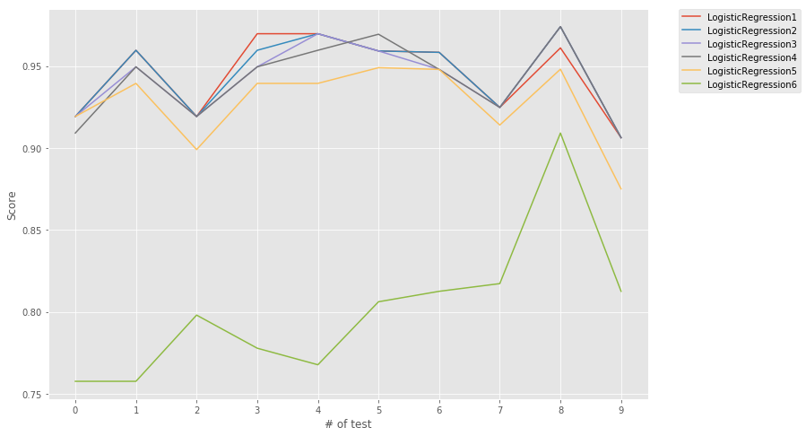

```
LogisticRegression2 has avg. accuracy of: 0.94497968909
LogisticRegression1 has avg. accuracy of: 0.944691088801
LogisticRegression3 has avg. accuracy of: 0.941917820403
LogisticRegression4 has avg. accuracy of: 0.940918026546
LogisticRegression5 has avg. accuracy of: 0.927029033754
LogisticRegression6 has avg. accuracy of: 0.801600351773
```

```python
mc.cross_validate(10)
mc.compr()
mc.comprAccAVG()
```

### Performance on test data

```python
#get the precision, recall, f-score and support on test data for each model
mc.accOnTest(testX, testY)
```

```
LogisticRegression1
             precision    recall  f1-score   support

          2       1.00      1.00      1.00         1
          3       1.00      1.00      1.00         2
          4       1.00      1.00      1.00         2
          5       1.00      1.00      1.00         1
          6       1.00      1.00      1.00         1
          7       1.00      1.00      1.00         2
          8       1.00      1.00      1.00         2
          9       1.00      1.00      1.00         3
         10       1.00      1.00      1.00         1
         14       1.00      1.00      1.00         4
         15       1.00      1.00      1.00         1
         16       1.00      1.00      1.00         1
```

[output cut: 448 more lines]

```
LogisticRegression1
Normalized confusion matrix
[[ 1.  0.  0. ...,  0.  0.  0.]
 [ 0.  1.  0. ...,  0.  0.  0.]
 [ 0.  0.  1. ...,  0.  0.  0.]
 ...,
 [ 0.  0.  0. ...,  1.  0.  0.]
 [ 0.  0.  0. ...,  0.  1.  0.]
 [ 0.  0.  0. ...,  0.  0.  1.]]
```

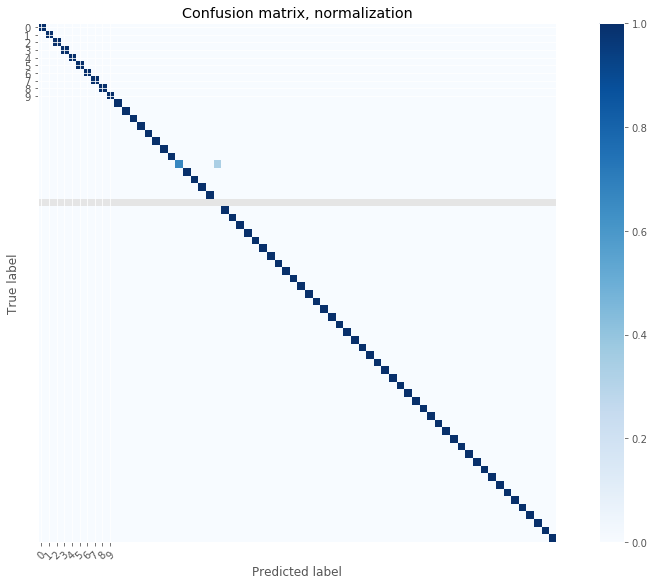

```python
mc.compareCMs([0])#get the confusion matrix for the test data
```

### Computing speed

```python
#compare the time for each model
mc.comprTime()
```

```
LogisticRegression1 has avg. computation time of: 2.347565174102783
LogisticRegression2 has avg. computation time of: 2.0843918323516846
LogisticRegression3 has avg. computation time of: 2.0423636436462402
LogisticRegression4 has avg. computation time of: 1.8122084140777588
LogisticRegression5 has avg. computation time of: 1.344897985458374
LogisticRegression6 has avg. computation time of: 0.9406783580780029
```

### Learning curve

A learning curve shows the validation and training score of an estimator for varying numbers of training samples. It is a tool to find out how much we benefit from adding more training data and whether the estimator suffers more from a variance error or a bias error.

If both the validation score and the training score converge to a value that is too low with increasing size of the training set, we will not benefit much from more training data.

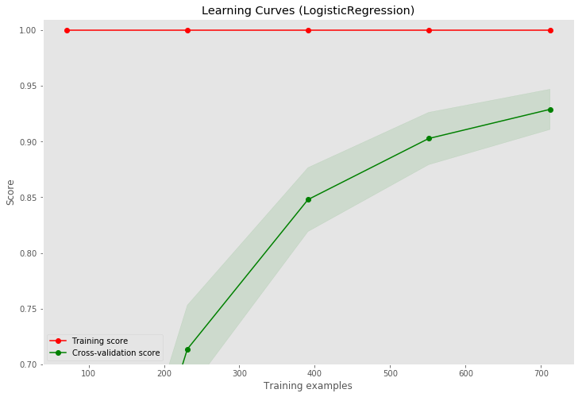

```python
from sklearn.model_selection import learning_curve
from sklearn.model_selection import ShuffleSplit
def plot_learning_curve(estimator, title, X, y, ylim=None, cv=None,
                        n_jobs=1, train_sizes=np.linspace(.1, 1.0, 5)):
    """
    Generate a simple plot of the test and training learning curve.
    Parameters
    ----------
    estimator : object type that implements the "fit" and "predict" methods
        An object of that type which is cloned for each validation.
    title : string
        Title for the chart.
    X : array-like, shape (n_samples, n_features)
        Training vector, where n_samples is the number of samples and
        n_features is the number of features.

    y : array-like, shape (n_samples) or (n_samples, n_features), optional
        Target relative to X for classification or regression;
        None for unsupervised learning.

    ylim : tuple, shape (ymin, ymax), optional
        Defines minimum and maximum yvalues plotted.

    cv : int, cross-validation generator or an iterable, optional
        Determines the cross-validation splitting strategy.
        Possible inputs for cv are:
          - None, to use the default 3-fold cross-validation,
          - integer, to specify the number of folds.
          - An object to be used as a cross-validation generator.
          - An iterable yielding train/test splits.

        For integer/None inputs, if ``y`` is binary or multiclass,
        :class:`StratifiedKFold` used. If the estimator is not a classifier
        or if ``y`` is neither binary nor multiclass, :class:`KFold` is used.

        Refer :ref:`User Guide <cross_validation>` for the various
        cross-validators that can be used here.

    n_jobs : integer, optional
        Number of jobs to run in parallel (default 1).
    """
    plt.figure()
    plt.title(title)
    if ylim is not None:
        plt.ylim(*ylim)
    plt.xlabel("Training examples")
    plt.ylabel("Score")
    train_sizes, train_scores, test_scores = learning_curve(
        estimator, X, y, cv=cv, n_jobs=n_jobs, train_sizes=train_sizes)
    train_scores_mean = np.mean(train_scores, axis=1)
    train_scores_std = np.std(train_scores, axis=1)
    test_scores_mean = np.mean(test_scores, axis=1)
    test_scores_std = np.std(test_scores, axis=1)
    plt.grid()

    plt.fill_between(train_sizes, train_scores_mean - train_scores_std,
                     train_scores_mean + train_scores_std, alpha=0.1,
                     color="r")
    plt.fill_between(train_sizes, test_scores_mean - test_scores_std,
                     test_scores_mean + test_scores_std, alpha=0.1, color="g")
    plt.plot(train_sizes, train_scores_mean, 'o-', color="r",
             label="Training score")
    plt.plot(train_sizes, test_scores_mean, 'o-', color="g",
             label="Cross-validation score")

    plt.legend(loc="best")
    return plt

title = "Learning Curves (LogisticRegression)"
# Cross validation with 100 iterations to get smoother mean test and train
# score curves, each time with 20% data randomly selected as a validation set.
cv = ShuffleSplit(n_splits=100, test_size=0.2, random_state=0)
estimator = logreg2
plot_learning_curve(estimator, title, trainX, trainY, ylim=(0.7, 1.01), cv=cv, n_jobs=4)
plt.show()
```

The above trend plot shows that we can build better model if we have more training data.

### Validation curve

If the training score and the validation score are both low, the estimator will be underfitting. If the training score is high and the validation score is low, the estimator is overfitting and otherwise it is working very well.

In the following, we will exploring how one specific parameter works on the training and cross-validation data accuracy.

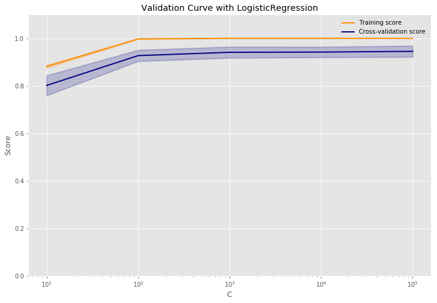

```python
from sklearn.model_selection import validation_curve
def get_validation_curve(model,trainX, trainY, param_name, param_range, model_name, cv = 10):
    train_scores, test_scores = validation_curve(
        model, trainX, trainY, param_name=param_name, param_range=param_range,
        cv=10, scoring="accuracy", n_jobs=1)
    train_scores_mean = np.mean(train_scores, axis=1)
    train_scores_std = np.std(train_scores, axis=1)
    test_scores_mean = np.mean(test_scores, axis=1)
    test_scores_std = np.std(test_scores, axis=1)

    plt.title("Validation Curve with " + model_name)
    plt.xlabel(param_name)
    plt.ylabel("Score")
    plt.ylim(0.0, 1.1)
    lw = 2
    plt.semilogx(param_range, train_scores_mean, label="Training score",
                 color="darkorange", lw=lw)
    plt.fill_between(param_range, train_scores_mean - train_scores_std,
                     train_scores_mean + train_scores_std, alpha=0.2,
                     color="darkorange", lw=lw)
    plt.semilogx(param_range, test_scores_mean, label="Cross-validation score",
                 color="navy", lw=lw)
    plt.fill_between(param_range, test_scores_mean - test_scores_std,
                     test_scores_mean + test_scores_std, alpha=0.2,
                     color="navy", lw=lw)
    plt.legend(loc="best")
    plt.show()

param_range = np.logspace(1,5,5)
get_validation_curve(logreg2, trainX, trainY,  "C", param_range,"LogisticRegression")
```

### Logistic regression with L1 regularization

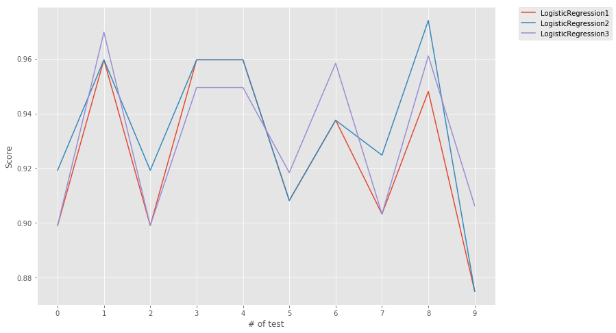

```
LogisticRegression2 has avg. accuracy of: 0.93365921393
LogisticRegression3 has avg. accuracy of: 0.931388211443
LogisticRegression1 has avg. accuracy of: 0.924870869658
```

```python
logreg7 = linear_model.LogisticRegression(penalty = 'l1', C=1e4, solver= 'liblinear')
logreg8 = linear_model.LogisticRegression(penalty = 'l1', C=1e3, solver= 'liblinear')
logreg9 = linear_model.LogisticRegression(penalty = 'l1', C=1e2, solver= 'liblinear')
mc = ModelCompr([logreg7,logreg8, logreg9], trainX, trainY)
mc.cross_validate(10)
mc.compr()
mc.comprAccAVG()
```

```python
print(logreg6.coef_)
print(logreg7.coef_) #Coefficient of the features in the decision function.
print(len(list(filter(lambda x:x!=0, logreg6.coef_[0]))))#the size of non-zero elements in logreg6's weight(l2 regularization)
print(len(list(filter(lambda x:x!=0, logreg7.coef_[0]))))#the size of non-zero elements in logreg7's weight(l1 regularization)
```

```
[[  2.90563075e-01  -5.89689529e+00   4.07868561e+00 ...,   3.39409174e-03
    1.30328249e-01  -1.42745921e-01]
 [  1.33616860e+00  -4.89699396e+00   4.64855480e+00 ...,  -2.69815396e-01
   -4.14556750e-01  -2.36298537e-01]
 [  4.47016956e+00  -1.02244424e+00   1.02249975e+00 ...,   1.41597972e-01
    2.26076930e-03   2.74511514e-02]
 ...,
 [  9.15516955e-01   1.64737219e+00  -3.65288678e+00 ...,   9.92372635e-02
    2.75531590e-01  -1.08720147e-02]
 [ -1.82947220e+00   2.74332765e+00   7.40555997e-01 ...,   5.76653910e-02
    1.98840361e-01  -3.05991290e-01]
 [ -1.44240788e-01  -3.15287387e+00  -2.67799878e+00 ...,   2.32231406e-01
   -1.45431248e-02   3.25963047e-01]]
[[  -5.10304733 -219.05981625    7.23183832 ...,    0.            0.            0.        ]
 [   0.           -7.19564947   27.60292389 ...,    0.            0.            0.        ]
 [   8.07772329  -11.44973332   12.61423733 ...,    0.            0.            0.        ]
 ...,
 [  22.59088822   29.78206471  -57.92596149 ...,    0.            7.90850681
     0.        ]
 [   0.           23.38855255    0.         ...,    0.            0.            0.        ]
 [  -1.11104065  -11.99328691  -12.03666809 ...,    0.            0.            0.        ]]
87
16
```

We can see the L1 regularization has a effect of feature selection. The weights of those trivial features will be set to zeros.

## SVM

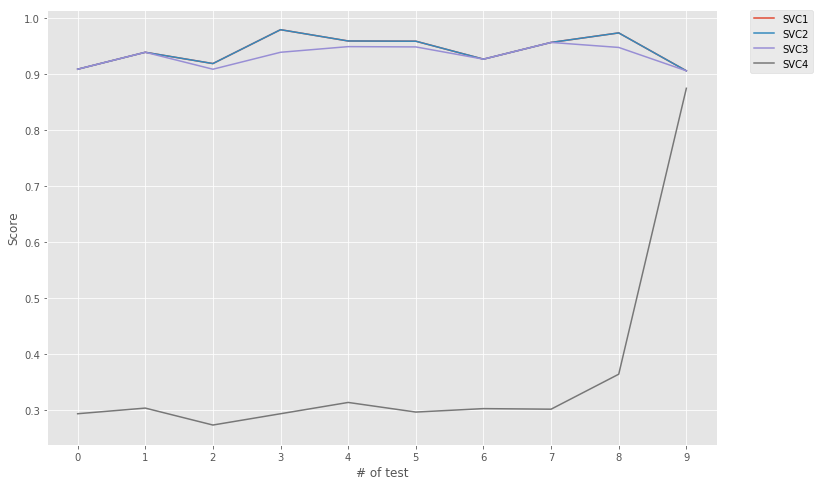

```
SVC1 has avg. accuracy of: 0.943060293521
SVC2 has avg. accuracy of: 0.943060293521
SVC3 has avg. accuracy of: 0.9333818767
SVC4 has avg. accuracy of: 0.361246080788
```

```python
svm1 = SVC(C = 1e5, kernel="rbf", gamma = 'auto')
svm2 = SVC(C = 1e4, kernel="rbf", gamma = 'auto')
svm3 = SVC(C = 1e3, kernel="rbf", gamma = 'auto')
svm4 = SVC(C = 1e1, kernel="rbf", gamma = 'auto')
mc = ModelCompr([svm1, svm2, svm3, svm4], trainX, trainY)
mc.cross_validate(10)
mc.compr()
mc.comprAccAVG()
```

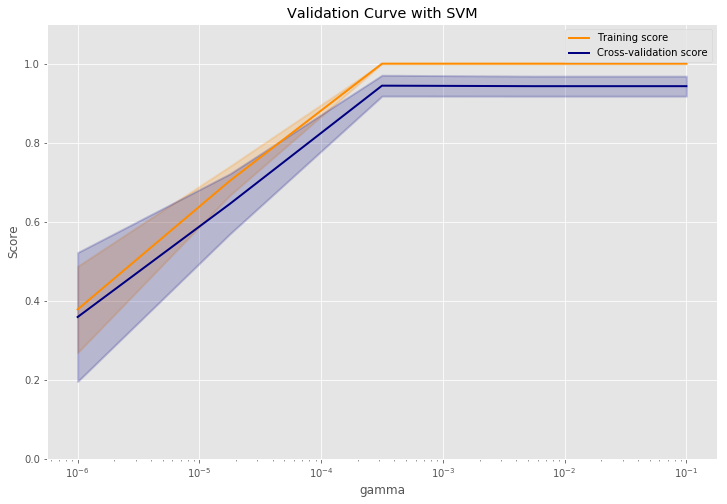

```python
param_range = np.logspace(-1,-6,5)
get_validation_curve(svm1, trainX, trainY,  "gamma", param_range,"SVM")
```

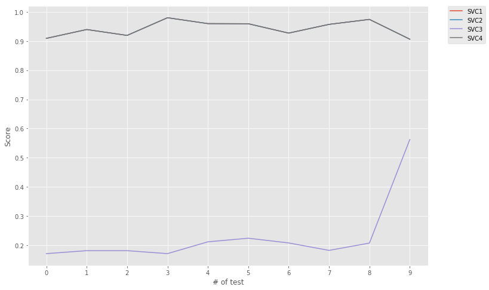

```python
import warnings
warnings.filterwarnings("ignore")
svm1 = SVC(C = 1e5,kernel="rbf", gamma = 'auto')
svm2 = SVC(C = 1e5,kernel="linear", gamma = 'auto')
svm3 = SVC(C = 1e5,kernel="poly", gamma = 'auto') #pooor performance
svm4 = SVC(C = 1e5,kernel="sigmoid", gamma = 'auto')
mc = ModelCompr([svm1, svm2, svm3, svm4], trainX, trainY)
mc.cross_validate(10)
mc.compr()
```

## Neural Networks

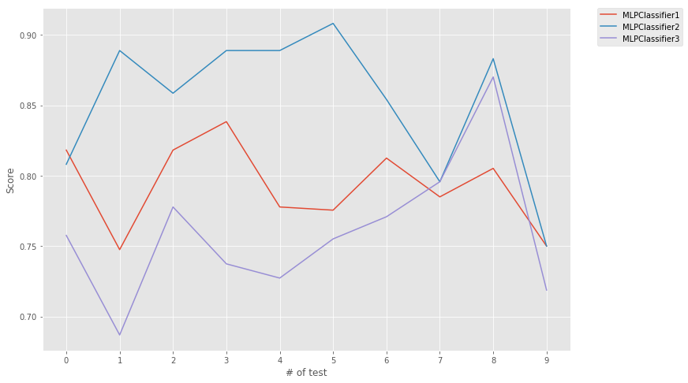

```python
from sklearn.neural_network import MLPClassifier
nn1 =  MLPClassifier(activation='tanh', solver='lbfgs', alpha=1e-6, hidden_layer_sizes=(128, 99), random_state=1)
nn2 =  MLPClassifier(activation='relu', solver='lbfgs', alpha=1e-6, hidden_layer_sizes=(128, 99), random_state=1)
nn3 =  MLPClassifier(activation='relu', solver='lbfgs', alpha=1e-6, hidden_layer_sizes=(64, 32), random_state=1)
mc = ModelCompr([nn1, nn2, nn3], trainX, trainY)
mc.cross_validate(10)
mc.compr()
```

## Random Forest

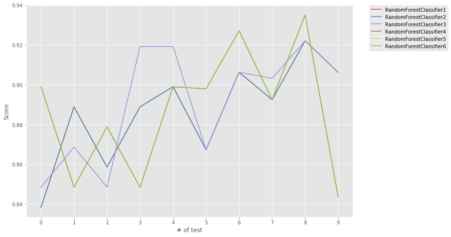

```python
rf1 = RandomForestClassifier(n_estimators=100, bootstrap=True, criterion='gini', max_depth=None, random_state=0)
rf2 = RandomForestClassifier(n_estimators=100, bootstrap=True, criterion='gini', max_depth=50, random_state=0)
rf3 = RandomForestClassifier(n_estimators=100, bootstrap=True, criterion='gini', max_depth=20, random_state=0)
rf4 = RandomForestClassifier(n_estimators=100, bootstrap=True, criterion='entropy', max_depth=None, random_state=0)
rf5 = RandomForestClassifier(n_estimators=100, bootstrap=True, criterion='entropy', max_depth=50, random_state=0)
rf6 = RandomForestClassifier(n_estimators=100, bootstrap=True, criterion='entropy', max_depth=20, random_state=0)
mc = ModelCompr([rf1,rf2,rf3,rf4,rf5,rf6], trainX, trainY)
mc.cross_validate(10)
mc.compr()
```

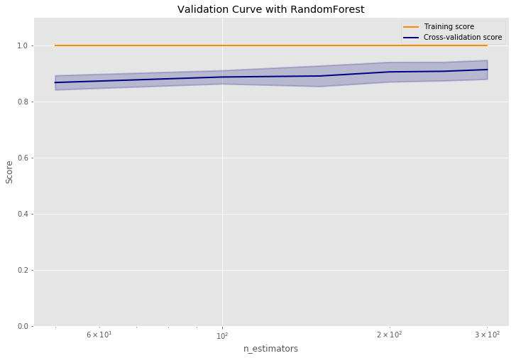

```python
param_range = [i*50 for i in range(1,7)]
get_validation_curve(rf1, trainX, trainY, "n_estimators", param_range,"RandomForest")
```

## Comparison of all algorithms

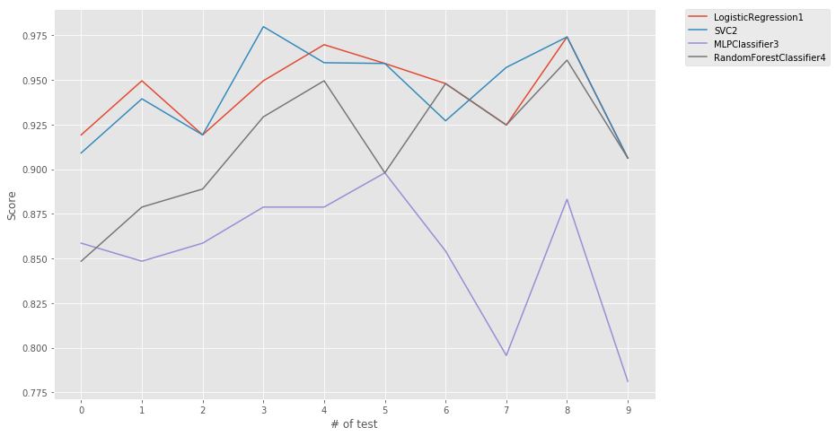

```python
logreg = linear_model.LogisticRegression(penalty = 'l2', C=1e4, solver= 'liblinear')
svm = SVC(C = 1e5,kernel="rbf", gamma = 'auto')
nn =  MLPClassifier(activation='relu', solver='lbfgs', alpha=1e-7, hidden_layer_sizes=(128, 99), random_state=1)
rf = RandomForestClassifier(n_estimators=300, bootstrap=True, criterion='gini', max_depth=None, random_state=0)
mc = ModelCompr([logreg, svm, nn, rf], trainX, trainY)
mc.cross_validate(10)
mc.compr()
```

```python
mc.comprAccAVG()
```

```
SVC2 has avg. accuracy of: 0.943060293521
LogisticRegression1 has avg. accuracy of: 0.941917820403
RandomForestClassifier4 has avg. accuracy of: 0.913284548912
MLPClassifier3 has avg. accuracy of: 0.853542398142
```

```python
mc.accOnTest(testX, testY)
```

```
LogisticRegression1
             precision    recall  f1-score   support

          2       1.00      1.00      1.00         1
          3       1.00      1.00      1.00         2
          4       1.00      1.00      1.00         2
          5       1.00      1.00      1.00         1
          6       1.00      1.00      1.00         1
          7       1.00      1.00      1.00         2
          8       1.00      1.00      1.00         2
          9       1.00      1.00      1.00         3
         10       1.00      1.00      1.00         1
         14       1.00      1.00      1.00         4
         15       1.00      1.00      1.00         1
         16       1.00      1.00      1.00         1
```

[output cut: 290 more lines]

```
LogisticRegression1
Normalized confusion matrix
[[ 1.  0.  0. ...,  0.  0.  0.]
 [ 0.  1.  0. ...,  0.  0.  0.]
 [ 0.  0.  1. ...,  0.  0.  0.]
 ...,
 [ 0.  0.  0. ...,  1.  0.  0.]
 [ 0.  0.  0. ...,  0.  1.  0.]
 [ 0.  0.  0. ...,  0.  0.  1.]]
```

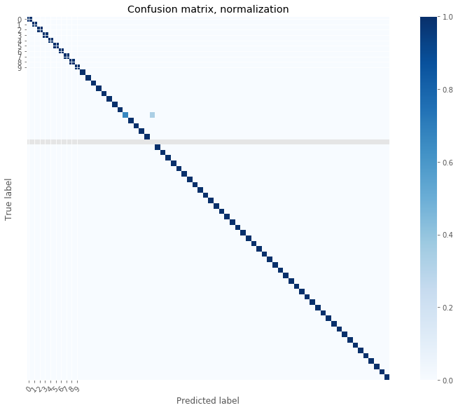

```
------------------------------------------------------
SVC2
Normalized confusion matrix
[[ 1.  0.  0. ...,  0.  0.  0.]
 [ 0.  1.  0. ...,  0.  0.  0.]
 [ 0.  0.  1. ...,  0.  0.  0.]
 ...,
 [ 0.  0.  0. ...,  1.  0.  0.]
 [ 0.  0.  0. ...,  0.  1.  0.]
 [ 0.  0.  0. ...,  0.  0.  1.]]
```

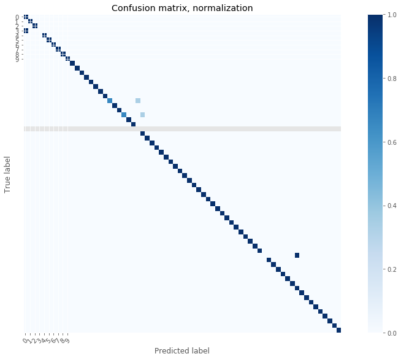

```
------------------------------------------------------
MLPClassifier3
Normalized confusion matrix
[[ 1.  0.  0. ...,  0.  0.  0.]
 [ 0.  1.  0. ...,  0.  0.  0.]
 [ 0.  0.  1. ...,  0.  0.  0.]
 ...,
 [ 0.  0.  0. ...,  1.  0.  0.]
 [ 0.  0.  0. ...,  0.  1.  0.]
 [ 0.  0.  0. ...,  0.  0.  1.]]
```

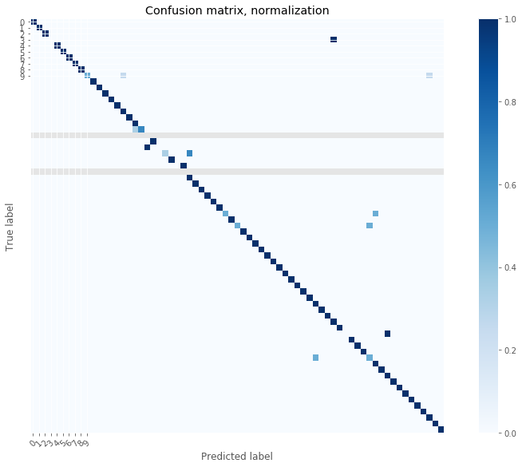

```
------------------------------------------------------
RandomForestClassifier4
Normalized confusion matrix
[[ 1.  0.  0. ...,  0.  0.  0.]
 [ 0.  1.  0. ...,  0.  0.  0.]
 [ 0.  0.  1. ...,  0.  0.  0.]
 ...,
 [ 0.  0.  0. ...,  1.  0.  0.]
 [ 0.  0.  0. ...,  0.  1.  0.]
 [ 0.  0.  0. ...,  0.  0.  1.]]
```

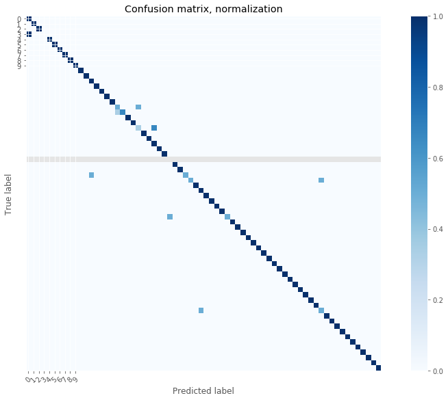

```python
mc.compareCMs([0,1,2,3])
```

```python
mc.comprTime()
```

```
MLPClassifier3 has avg. computation time of: 8.201469421386719
RandomForestClassifier4 has avg. computation time of: 7.074038028717041
LogisticRegression1 has avg. computation time of: 1.7741858959197998
SVC2 has avg. computation time of: 0.20113420486450195
```

# Feature selection and model improvement

Given an external estimator that assigns weights to features (e.g., the coefficients of a linear model), **recursive feature elimination (RFE)** is to select features by recursively considering smaller and smaller sets of features. First, the estimator is trained on the initial set of features and the importance of each feature is obtained either through a coef_ attribute or through a feature*importances* attribute. Then, the least important features are pruned from current set of features.That procedure is recursively repeated on the pruned set until the desired number of features to select is eventually reached.

We can also use **L1-based feature selection** or **Tree-based feature selection**.

```python
from sklearn.model_selection import StratifiedKFold
from sklearn.feature_selection import RFECV
from sklearn.datasets import make_classification
```

```python
class FeatureSelection:
    """
    Given a model, impletement FS.
    Feature ranking with recursive feature elimination and cross-validated
    selection of the best number of features.
    rfecv. support_ :array of shape [n_features] : The mask of selected features.
    rfecv.ranking_:
    The feature ranking, such that ranking_[i] corresponds to the ranking position of the i-th feature.
    Selected (i.e., estimated best) features are assigned rank 1.
    """
    def __init__(self, model, trainX, trainY, k = 2, scoring = "accuracy"):
        self.model = model #the model you use
        self.X = trainX #training data input
        self.Y = trainY #training data labels
        self.k = k #fold number
        self.scoring = scoring #criteria
        self.rfecv = None
        self.y_train_pred = self.model.predict(self.X)
        self.already_selected = False
    def featureSelection(self):
        """
        Perform feature selection via cv.
        """
        self.rfecv = RFECV(estimator=self.model, step=1, cv=StratifiedKFold(self.k), scoring=self.scoring)
        self.rfecv.fit(self.X, self.Y)
        print("Optimal number of features : %d" % self.rfecv.n_features_)
        self.X_r = self.rfecv.transform(self.X)
        self.model.fit(self.X_r, self.Y)
        self.new_y_train_pred = self.model.predict(self.X_r)

    def showPlot(self):
        """
        Plot the change of cv score versus the numbers of features selected
        """
        self.featureSelection()
        self.already_selected = True
        # Plot number of features VS. cross-validation scores
        plt.figure()
        plt.xlabel("Number of features selected")
        plt.ylabel("Cross validation score (nb of correct classifications)")
        plt.plot(range(1, len(self.rfecv.grid_scores_) + 1), self.rfecv.grid_scores_)
        plt.show()
    def report(self):
        """
        Report feature selection report.
        """
        if not self.already_selected:
            self.featureSelection()
        print("rfecv.support_: (features mask)")
        print (self.rfecv.support_)
        print("rfecv.ranking_: (ranking of the features)")
        print (self.rfecv.ranking_)
        print()
        print("Before feature selection: ")
        print(classification_report(self.Y, self.y_train_pred))
        print("After feature selection: ")
        print(classification_report(self.Y, self.new_y_train_pred))
```

```python
logreg = linear_model.LogisticRegression(penalty = 'l2', C=1e4, solver= 'liblinear')
logreg.fit(trainX, trainY) #fit the model before feature selection
fs = FeatureSelection(logreg, trainX, trainY, k=5) #build a FeatureSelection class to perform the task
```

```
Optimal number of features : 75
```

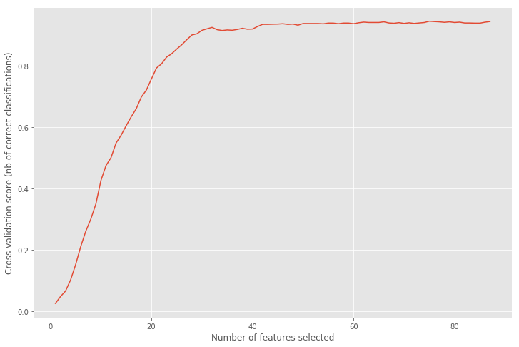

```python
fs.showPlot()
```

```python
fs.report()
```

```
rfecv.support_: (features mask)
[ True  True  True  True  True  True  True  True  True  True  True  True
  True  True  True  True  True  True  True  True  True  True  True  True
  True  True  True  True  True  True  True  True  True  True  True  True
  True  True  True  True  True  True  True  True  True  True  True  True
  True  True  True  True  True  True  True  True  True  True  True  True
  True  True  True  True False  True  True  True False  True  True  True
 False False  True  True  True False False False False False False  True
 False False  True]
rfecv.ranking_: (ranking of the features)
[ 1  1  1  1  1  1  1  1  1  1  1  1  1  1  1  1  1  1  1  1  1  1  1  1  1
  1  1  1  1  1  1  1  1  1  1  1  1  1  1  1  1  1  1  1  1  1  1  1  1  1
  1  1  1  1  1  1  1  1  1  1  1  1  1  1  3  1  1  1  6  1  1  1  8  2  1
  1  1  4 12  5  9 11  7  1 10 13  1]

```

[output cut: 209 more lines]

# Hyper-parameters tuning using grid search method

```python
from sklearn.model_selection import GridSearchCV
```

```python
# for a large dataset and complex model with many hyper-paramters, grid-search is not a good idea
# since we are not sure with hyper-parameter is more significant versus others
# thus grid search with will be very costly
def gridSearchTuning():
    # Set the parameters by cross-validation
    tuned_parameters = [{'kernel': ['rbf'], 'gamma': [1e-2, 1e-3, 1e-4],
                         'C': [1e3, 1e4, 1e5, 1e6]},
                        {'kernel': ['linear'], 'C': [1e3, 1e4, 1e5, 1e6]}]

    scores = ['precision', 'recall']

    for score in scores:
        print("# Tuning hyper-parameters for %s" % score)
        print()
        try:
            clf = GridSearchCV(SVC(), tuned_parameters, cv=5, scoring='%s_macro' % score)
            clf.fit(trainX, trainY)
        except:
            print("err")

        print("Best parameters set found on development set:")
        print()
        print(clf.best_params_)
        print()
        print("Grid scores on development set:")
        print()
        means = clf.cv_results_['mean_test_score']
        stds = clf.cv_results_['std_test_score']
        for mean, std, params in zip(means, stds, clf.cv_results_['params']):
            print("%0.3f (+/-%0.03f) for %r" % (mean, std * 2, params))
        print()

        print("Detailed classification report:")
        print()
        print("The model is trained on the full development set.")
        print("The scores are computed on the full evaluation set.")
        print()
        y_true, y_pred = testY, clf.predict(testX)
        print(classification_report(y_true, y_pred))
        print()


gridSearchTuning()
```

```
# Tuning hyper-parameters for precision

Best parameters set found on development set:

{'C': 10000.0, 'gamma': 0.01, 'kernel': 'rbf'}

Grid scores on development set:

0.921 (+/-0.046) for {'C': 1000.0, 'gamma': 0.01, 'kernel': 'rbf'}
0.310 (+/-0.251) for {'C': 1000.0, 'gamma': 0.001, 'kernel': 'rbf'}
0.208 (+/-0.282) for {'C': 1000.0, 'gamma': 0.0001, 'kernel': 'rbf'}
0.947 (+/-0.023) for {'C': 10000.0, 'gamma': 0.01, 'kernel': 'rbf'}
0.921 (+/-0.046) for {'C': 10000.0, 'gamma': 0.001, 'kernel': 'rbf'}
0.310 (+/-0.251) for {'C': 10000.0, 'gamma': 0.0001, 'kernel': 'rbf'}
0.947 (+/-0.023) for {'C': 100000.0, 'gamma': 0.01, 'kernel': 'rbf'}
0.947 (+/-0.023) for {'C': 100000.0, 'gamma': 0.001, 'kernel': 'rbf'}
0.920 (+/-0.046) for {'C': 100000.0, 'gamma': 0.0001, 'kernel': 'rbf'}
0.947 (+/-0.023) for {'C': 1000000.0, 'gamma': 0.01, 'kernel': 'rbf'}
0.947 (+/-0.023) for {'C': 1000000.0, 'gamma': 0.001, 'kernel': 'rbf'}
0.946 (+/-0.024) for {'C': 1000000.0, 'gamma': 0.0001, 'kernel': 'rbf'}
0.947 (+/-0.023) for {'C': 1000.0, 'kernel': 'linear'}
0.947 (+/-0.023) for {'C': 10000.0, 'kernel': 'linear'}
0.947 (+/-0.023) for {'C': 100000.0, 'kernel': 'linear'}
0.947 (+/-0.023) for {'C': 1000000.0, 'kernel': 'linear'}

Detailed classification report:

The model is trained on the full development set.
The scores are computed on the full evaluation set.

             precision    recall  f1-score   support

          2       0.50      1.00      0.67         1
          3       1.00      1.00      1.00         2
          4       1.00      1.00      1.00         2
          5       0.00      0.00      0.00         1
          6       1.00      1.00      1.00         1
          7       1.00      1.00      1.00         2
          8       1.00      1.00      1.00         2
          9       1.00      1.00      1.00         3
```

[output cut: 151 more lines]

```
         81       1.00      1.00      1.00         2
         83       1.00      1.00      1.00         2
         84       1.00      1.00      1.00         1
         86       0.83      1.00      0.91         5
         87       1.00      1.00      1.00         1
         88       1.00      1.00      1.00         1
         90       1.00      1.00      1.00         1
         92       1.00      1.00      1.00         1
         93       1.00      1.00      1.00         1
         94       1.00      1.00      1.00         1
         95       1.00      1.00      1.00         2
         96       1.00      1.00      1.00         1
         98       1.00      1.00      1.00         1

avg / total       0.96      0.96      0.96        99
```